# Predicting Loan Risk

### Try to improve model by balanced data

**ROSE** (Random Over-Sampling Ex- amples) is a [bootstrap-based technique](https://journal.r-project.org/archive/2014/RJ-2014-008/RJ-2014-008.pdf) which aids the task of binary classification in the presence of imbalanced classes. It handles both continuous and categorical data and produces a synthetic, possibly balanced, sample of data simulated according to a smoothed-bootstrap approach.

References:

- [Testing imbalanced data on Credit Card Fraud Detection](https://www.kaggle.com/pritamjena/testing-the-imbalanced-data-using-rose-package)
- [Subsampling for class imbalance](https://topepo.github.io/caret/subsampling-for-class-imbalances.html)
- [ROSE and SMOTE oversampling methods](https://stats.stackexchange.com/questions/166458/rose-and-smote-oversampling-methods)

```r
# ROSE package requires numeric data or categorical data as factor.  Since categorical data is right now chracter, convert.

str(train.data)
```

```
## Classes 'data.table' and 'data.frame':   908333 obs. of  15 variables:
##  $ loan_status   : Factor w/ 2 levels "0","1": 2 2 2 2 2 2 2 2 2 2 ...
##  $ grade         : chr  "D" "B" "B" "C" ...
##  $ open_acc      : num  11 12 6 3 21 4 17 6 15 20 ...
##  $ pub_rec       : num  1 0 0 0 1 0 0 0 0 0 ...
##  $ dti           : num  30.46 4.64 16.21 15.09 24.95 ...
##  $ delinq_2yrs   : num  0 0 0 0 0 0 0 0 0 0 ...
##  $ inq_last_6mths: num  0 0 0 0 0 0 0 0 1 1 ...
##  $ emp_length    : chr  "5 years" "10+ years" "10+ years" "5 years" ...
##  $ annual_inc    : num  100000 38500 45000 42000 24000 60000 250000 98000 55000 58000 ...
##  $ home_ownership: chr  "MORTGAGE" "RENT" "RENT" "RENT" ...
##  $ addr_state    : chr  "CA" "TX" "TX" "PA" ...
##  $ loan_amnt     : num  30000 4500 6600 2500 2700 ...
##  $ issue_d       : chr  "Dec-2018" "Dec-2018" "Dec-2018" "Dec-2018" ...
##  $ revol_bal     : num  15603 4472 6167 3319 2696 ...
##  $ revol_util    : num  0.37 0.153 0.582 0.316 0.364 0.728 0.612 0.551 0.05 0.183 ...
##  - attr(*, ".internal.selfref")=<externalptr>
```

```r
colnames(train.data %>% select_if(Negate(is.numeric)))
```

```
## [1] "loan_status"    "grade"          "emp_length"     "home_ownership"
## [5] "addr_state"     "issue_d"
```

```r
train.data$grade <- as.factor(train.data$grade)
train.data$emp_length <- as.factor(train.data$emp_length)
train.data$home_ownership <- as.factor(train.data$home_ownership)
train.data$addr_state <- as.factor(train.data$addr_state)
train.data$issue_d <- as.factor(train.data$issue_d)

str(train.data)
```

```
## Classes 'data.table' and 'data.frame':   908333 obs. of  15 variables:
##  $ loan_status   : Factor w/ 2 levels "0","1": 2 2 2 2 2 2 2 2 2 2 ...
##  $ grade         : Factor w/ 7 levels "A","B","C","D",..: 4 2 2 3 1 5 1 1 1 2 ...
##  $ open_acc      : num  11 12 6 3 21 4 17 6 15 20 ...
##  $ pub_rec       : num  1 0 0 0 1 0 0 0 0 0 ...
##  $ dti           : num  30.46 4.64 16.21 15.09 24.95 ...
##  $ delinq_2yrs   : num  0 0 0 0 0 0 0 0 0 0 ...
##  $ inq_last_6mths: num  0 0 0 0 0 0 0 0 1 1 ...
##  $ emp_length    : Factor w/ 12 levels "< 1 year","1 year",..: 7 3 3 7 6 5 3 7 3 3 ...
##  $ annual_inc    : num  100000 38500 45000 42000 24000 60000 250000 98000 55000 58000 ...
##  $ home_ownership: Factor w/ 6 levels "ANY","MORTGAGE",..: 2 6 6 6 5 6 2 2 2 2 ...
##  $ addr_state    : Factor w/ 51 levels "AK","AL","AR",..: 5 44 44 39 23 36 5 44 4 35 ...
##  $ loan_amnt     : num  30000 4500 6600 2500 2700 ...
##  $ issue_d       : Factor w/ 139 levels "Apr-2008","Apr-2009",..: 35 35 35 35 35 35 35 35 35 35 ...
##  $ revol_bal     : num  15603 4472 6167 3319 2696 ...
##  $ revol_util    : num  0.37 0.153 0.582 0.316 0.364 0.728 0.612 0.551 0.05 0.183 ...
##  - attr(*, ".internal.selfref")=<externalptr>
```

```r
#Making balanced data using SDG method
balanced.data <- ROSE(loan_status ~ ., data = train.data, seed = 1)$data

# check (im)balance of new data
table(balanced.data$loan_status) #Now we have almost 50% 50%
```

```
##
##      1      0
## 453777 454556
```

How to read the ROSE function above: - The first argument (loan_status ~ .) is the `formula` object. It is often used to denote a statistical model, where the part to the left of the `~` is the response variable and the part to the right of the `~` are the explanatory variables. Using the dot (`.`) means “all variables not yet used” from train.data.

So in English you’d say something like, loan_status depends on grade, open_acc, pub_rec, …, etc.

`help("~")` or `help("formula")` will teach you more.

The `$` allows you extract elements by name from a named list. For example if you run `names(ROSE(loan_status ~ ., data = tdn, seed = 1))` you get `[1] "Call" "method" "data"`. So ROSE(loan_status ~ ., data = tdn, seed = 1)$data let’s you store just the data part into balanced.data.

References:

- [Meaning of tilda](https://stackoverflow.com/questions/14976331/use-of-tilde-in-r-programming-language/14976479)
- [Meaning of $](https://stackoverflow.com/questions/42560090/what-is-the-meaning-of-the-dollar-sign-in-r-function)

```r
#Building new logistic regression model
rose.regressor <- glm(loan_status ~ ., family = "binomial", data = balanced.data)
summary(rose.regressor)
```

```
##
## Call:
## glm(formula = loan_status ~ ., family = "binomial", data = balanced.data)
##
## Deviance Residuals:
##     Min       1Q   Median       3Q      Max
## -2.3375  -1.0651   0.4526   1.0358   3.4556
##
## Coefficients:
##                              Estimate     Std. Error z value
## (Intercept)            -2.15906579034  0.26377179551  -8.185
## gradeB                  0.76355456266  0.00862621197  88.516
## gradeC                  1.30379038580  0.00858978181 151.784
## gradeD                  1.67506010328  0.00941771939 177.863
## gradeE                  1.99173870738  0.01104959967 180.254
## gradeF                  2.24951077429  0.01571472095 143.147
## gradeG                  2.39069166635  0.02722308097  87.819
## open_acc                0.01065657689  0.00043745469  24.360
## pub_rec                 0.03941486844  0.00367326734  10.730
## dti                     0.01350584340  0.00028679124  47.093
## delinq_2yrs             0.02936210353  0.00240129235  12.228
## inq_last_6mths          0.07020370352  0.00231535730  30.321
## emp_length1 year        0.01599696034  0.01179132010   1.357
## emp_length10+ years    -0.05955221892  0.00901105026  -6.609
## emp_length2 years      -0.03900063371  0.01093454612  -3.567
## emp_length3 years      -0.01951129851  0.01125498748  -1.734
## emp_length4 years      -0.05625427838  0.01218437903  -4.617
## emp_length5 years      -0.01407500260  0.01202231994  -1.171
## emp_length6 years      -0.03660162507  0.01316042578  -2.781
## emp_length7 years      -0.01355971987  0.01337930743  -1.013
## emp_length8 years       0.00831742279  0.01325552332   0.627
## emp_length9 years      -0.00353736386  0.01408901152  -0.251
## emp_lengthn/a           0.38589244454  0.01214372412  31.777
## annual_inc             -0.00000208507  0.00000005651 -36.897
## home_ownershipMORTGAGE -0.03452681171  0.15494762285  -0.223
## home_ownershipNONE      0.81598693553  0.40921282040   1.994
## home_ownershipOTHER     0.45812236132  0.26917702502   1.702
## home_ownershipOWN       0.11794576110  0.15505477590   0.761
## home_ownershipRENT      0.30051261819  0.15494538191   1.939
## addr_stateAL            0.20254884602  0.05037591125   4.021
```

[output cut: 404 more lines]

```
## issue_dSep-2016                    0.045749 *
## issue_dSep-2017                    0.063632 .
## issue_dSep-2018        0.000000000005577466 ***
## revol_bal              < 0.0000000000000002 ***
## revol_util             < 0.0000000000000002 ***
## ---
## Signif. codes:  0 '***' 0.001 '**' 0.01 '*' 0.05 '.' 0.1 ' ' 1
##
## (Dispersion parameter for binomial family taken to be 1)
##
##     Null deviance: 1259216  on 908332  degrees of freedom
## Residual deviance: 1129748  on 908114  degrees of freedom
## AIC: 1130186
##
## Number of Fisher Scoring iterations: 8
```

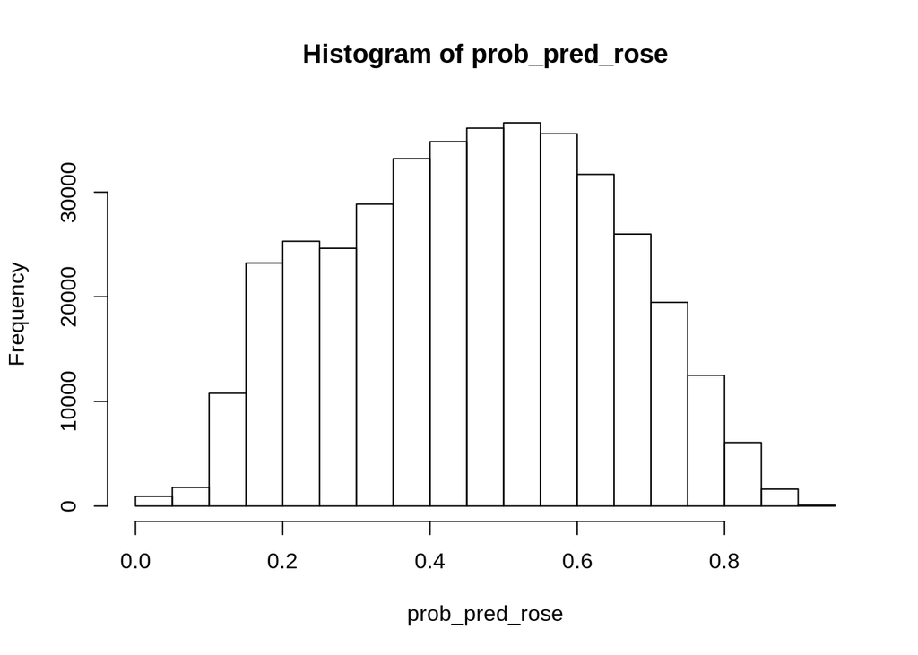

```r
#Making predictions on test set
prob_pred_rose <- predict(rose.regressor, newdata = test.data, type="response")
hist(prob_pred_rose)
```

```r
#Evaluating new model
roc.curve(test.data$loan_status, prob_pred_rose, col="dark red", main="The ROC-curve for Improved Model")
```

```
## Area under the curve (AUC): 0.713
```

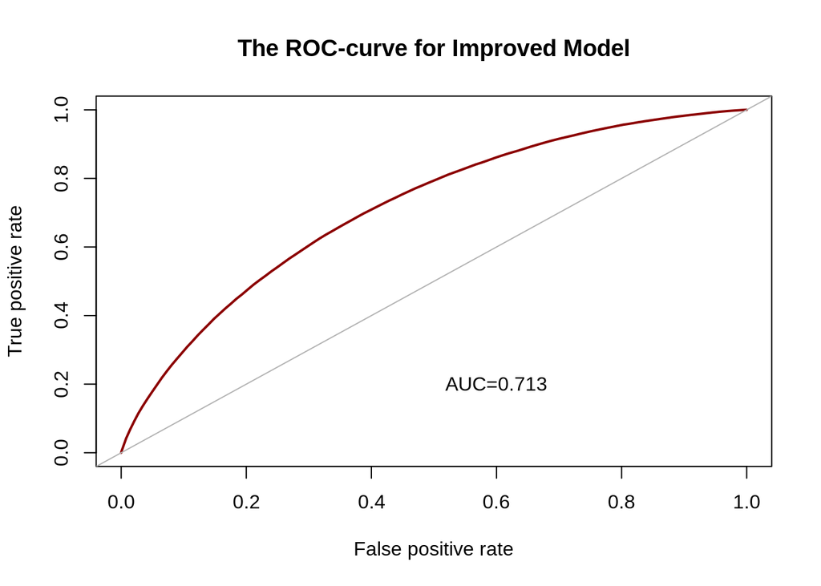

```r
text(0.6,0.2,paste("AUC=0.713"))
```

### Notes on using R Notebook: